# pri_miRNAs dgCMatrix create

Skim

2020 5 5

This Report is overview of pri-miRNA in AD snRNA-seq data.

I used annotation of microRNA primary transcript from Chang et al., Genome Res. 2015 [ref](https://genome.cshlp.org/content/early/2015/08/07/gr.193607.115.abstract) To summarize, a computational pipeline was developed that produces highly accurate pri-miRNA assemblies from both human and mouse cell lines, as confirmed by extensive validation. I modified GTF assemblies pri-miRNA from 378 miRNAs. I checked with pre-miRNAs and all of them are within the pri-miRNAs coordinates. Overall, 56% of pri-miRNAs were in protein coding region. From there pri-miRNAs from 337 miRNAs were detected in our data.

```r
.libPaths(c("/home/skim/R/usr_lib", .libPaths()))
library(Seurat)
library(ggplot2)
library(gridExtra)
library(grid)
library(ggrepel)
library(DT)
library(biomaRt)
library(dplyr)
library(viridis)
library(tidyr)
#library(remotes)
#devtools::install_github("AllenInstitute/scrattch.io", lib.loc="/data/rajewsky/shared_libs/R/")
#library(rhdf5)
```

```r
# #####################
# # load SP064_022_pri
# ######################
# SP064_022_pri <- Read10X("/data/rajewsky/home/skim/Microglia_Heppner/201912_10X_9sets/miRNA_lncRNA/SP064_022_whole_pri_miRNA/outs/raw_feature_bc_matrix/")
#
# SP064_022_pri_sub <- SP064_022_pri[,colnames(SP064_022_pri) %in% colnames(SP064_all)]
#
# ######################
# # load SP064_023_pri
# ######################
# SP064_023_pri <- Read10X("/data/rajewsky/home/skim/Microglia_Heppner/201912_10X_9sets/miRNA_lncRNA/SP064_023_whole_pri_miRNA/outs/raw_feature_bc_matrix/")
#
# colnames(SP064_023_pri) <- paste0(substr(colnames(SP064_023_pri), 1,17),2)
#
# SP064_023_pri_sub <- SP064_023_pri[,colnames(SP064_023_pri) %in% colnames(SP064_all)]
#
# ######################
# # load SP064_024_pri
# ######################
# SP064_024_pri <- Read10X("/data/rajewsky/home/skim/Microglia_Heppner/201912_10X_9sets/miRNA_lncRNA/SP064_024_whole_pri_miRNA/outs/raw_feature_bc_matrix/")
#
# colnames(SP064_024_pri) <- paste0(substr(colnames(SP064_024_pri), 1,17),3)
#
# SP064_024_pri_sub <- SP064_024_pri[,colnames(SP064_024_pri) %in% colnames(SP064_all)]
#
# ######################
# # load SP064_025_pri
# ######################
# SP064_025_pri <- Read10X("/data/rajewsky/home/skim/Microglia_Heppner/201912_10X_9sets/miRNA_lncRNA/SP064_025_whole_pri_miRNA/outs/raw_feature_bc_matrix/")
#
# colnames(SP064_025_pri) <- paste0(substr(colnames(SP064_025_pri), 1,17),4)
#
# SP064_025_pri_sub <- SP064_025_pri[,colnames(SP064_025_pri) %in% colnames(SP064_all)]
#
# ######################
# # load SP064_026_pri
# ######################
# SP064_026_pri <- Read10X("/data/rajewsky/home/skim/Microglia_Heppner/201912_10X_9sets/miRNA_lncRNA/SP064_026_whole_pri_miRNA/outs/raw_feature_bc_matrix/")
#
# colnames(SP064_026_pri) <- paste0(substr(colnames(SP064_026_pri), 1,17),5)
#
# SP064_026_pri_sub <- SP064_026_pri[,colnames(SP064_026_pri) %in% colnames(SP064_all)]
#
#
# ######################
# # load SP064_027_pri
# ######################
# SP064_027_pri <- Read10X("/data/rajewsky/home/skim/Microglia_Heppner/201912_10X_9sets/miRNA_lncRNA/SP064_027_whole_pri_miRNA/outs/raw_feature_bc_matrix/")
#
# colnames(SP064_027_pri) <- paste0(substr(colnames(SP064_027_pri), 1,17),6)
#
# SP064_027_pri_sub <- SP064_027_pri[,colnames(SP064_027_pri) %in% colnames(SP064_all)]
#
# ######################
# # load SP064_028_pri
# ######################
# SP064_028_pri <- Read10X("/data/rajewsky/home/skim/Microglia_Heppner/201912_10X_9sets/miRNA_lncRNA/SP064_028_whole_pri_miRNA/outs/raw_feature_bc_matrix/")
#
# colnames(SP064_028_pri) <- paste0(substr(colnames(SP064_028_pri), 1,17),7)
#
# SP064_028_pri_sub <- SP064_028_pri[,colnames(SP064_028_pri) %in% colnames(SP064_all)]
#
# ######################
# # load SP064_029_pri
# ######################
# SP064_029_pri <- Read10X("/data/rajewsky/home/skim/Microglia_Heppner/201912_10X_9sets/miRNA_lncRNA/SP064_029_whole_pri_miRNA/outs/raw_feature_bc_matrix/")
#
# colnames(SP064_029_pri) <- paste0(substr(colnames(SP064_029_pri), 1,17),8)
#
# SP064_029_pri_sub <- SP064_029_pri[,colnames(SP064_029_pri) %in% colnames(SP064_all)]
#
# ######################
# # load SP064_030_pri
# ######################
# SP064_030_pri <- Read10X("/data/rajewsky/home/skim/Microglia_Heppner/201912_10X_9sets/miRNA_lncRNA/SP064_030_whole_pri_miRNA/outs/raw_feature_bc_matrix/")
#
# colnames(SP064_030_pri) <- paste0(substr(colnames(SP064_030_pri), 1,17),9)
#
# SP064_030_pri_sub <- SP064_030_pri[,colnames(SP064_030_pri) %in% colnames(SP064_all)]
#
# ####################
# # Merge pri-miRNA &
# ####################
#
# SP064_pri_sub <- cbind(SP064_022_pri_sub, SP064_023_pri_sub, SP064_024_pri_sub, SP064_025_pri_sub, SP064_026_pri_sub, SP064_027_pri_sub,SP064_028_pri_sub, SP064_029_pri_sub, SP064_030_pri_sub)
#
# SP064_pri_sub.matrix <- as.matrix(SP064_pri_sub)
#
# write.table(SP064_pri_sub.matrix, "/data/rajewsky/home/skim/Microglia_Heppner/201912_10X_9sets/miRNA_lncRNA/R_Scripts/20200505_pri_miRNA_dgCMatrix_Create_SP064_pri_sub.txt")
```

```r
load(file="/data/rajewsky/home/skim/Microglia_Heppner/201912_10X_9sets/R_Scripts/20200210_figures_for_meeting_report_cleaned_Seurat_object_res0.8.Robj")

# load mRNA data
#SP064_all <- Read10X("/data/rajewsky/home/skim/Microglia_Heppner/201912_10X_9sets/SP064_All_025_3p/outs/filtered_feature_bc_matrix/")

# load pri-miRNA data
SP064_pri_sub.matrix <- read.table("/data/rajewsky/home/skim/Microglia_Heppner/201912_10X_9sets/miRNA_lncRNA/R_Scripts/20200505_pri_miRNA_dgCMatrix_Create_SP064_pri_sub.txt", check.names = FALSE)

SP064_pri_sub.matrix <- as.matrix(SP064_pri_sub.matrix)
SP064_pri_sub.dgCMatrix <- as(SP064_pri_sub.matrix, "dgCMatrix")
#SP064_all_merge <- rbind(SP064_all, SP064_pri_sub.dgCMatrix)

# subset by original file
SP064_pri_sub.dgCMatrix <- SP064_pri_sub.dgCMatrix[,Cells(data9set_cleaned.SO)]
```

```r
#length(rownames(SP064_pri_sub.dgCMatrix))

SP064_pri_sub_total <- as.data.frame(Matrix::rowSums(SP064_pri_sub.dgCMatrix))
colnames(SP064_pri_sub_total) <- "total_UMIs"

#str(SP064_pri_sub_total[SP064_pri_sub_total$total_UMIs > 0, ])
```

#### 1. Biotypes of reconstructed pri-miRNA assemblies

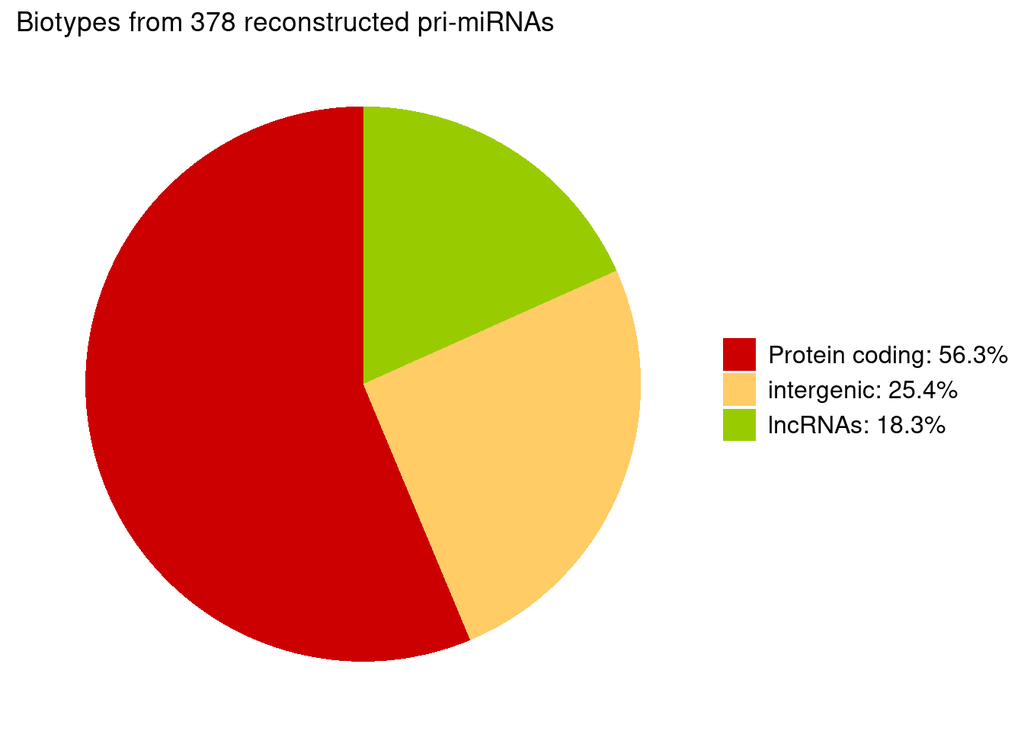

```r
host_biotype <- read.csv("/data/rajewsky/home/skim/Microglia_Heppner/201912_10X_9sets/miRNA_lncRNA/miRNA_gtf_whole_pri_miRNA_pre_miRNA/Extract_miRNA_host_gene_biotypes.csv", row.names = 1)

SP064_pri_sub.miRNA <- rownames(SP064_pri_sub.matrix) %>% as.data.frame

#unique(SP064_pri_sub.miRNA$.[SP064_pri_sub.miRNA$. %in% host_biotype$miRNA_ID])


no_host_gene <- data.frame(miRNA_ID = SP064_pri_sub.miRNA$.[!SP064_pri_sub.miRNA$. %in% host_biotype$miRNA_ID],
                           host_gene = "no_host_gene",
                           biotype = "intergenic")

host_biotype_final <- rbind(host_biotype, no_host_gene)

# save host_biotype_final
#write.csv(host_biotype_final, file = "/data/rajewsky/home/skim/Microglia_Heppner/201912_10X_9sets/miRNA_lncRNA/R_Scripts/20200505_pri_miRNA_dgCMatrix_Create_host_biotype_final.csv")

host_biotype_unique_final <- host_biotype_final[,c(1:3)]


host_biotype_unique_final <- host_biotype_unique_final[!duplicated(host_biotype_unique_final$miRNA_ID), ]


host_biotype_final.df <- as.data.frame(table(host_biotype_unique_final$biotype))

host_biotype_final.df$percent <- round(host_biotype_final.df$Freq / sum(host_biotype_final.df$Freq), 3)

ggplot(host_biotype_final.df, aes(x = 2, y= percent, fill = factor(percent, levels = c(0.563, 0.254, 0.183)))) +
  geom_bar(width = 1, stat = "identity") +
  ggtitle("Biotypes from 378 reconstructed pri-miRNAs ") +
  coord_polar(theta = "y", start=0) +
  theme_void() + theme(legend.text = element_text(size = 12), legend.title = element_blank()) +
  scale_fill_manual(values=c("#CC0000", "#FFCC66", "#99CC00"),
                    labels = c("Protein coding: 56.3%", "intergenic: 25.4%", "lncRNAs: 18.3%"))
```

#### 2. Biotypes of detected pri-miRNA in AD snRNA-seq data

378 miRNAs was detected in here and 337 miRNAs were more than 1 counts

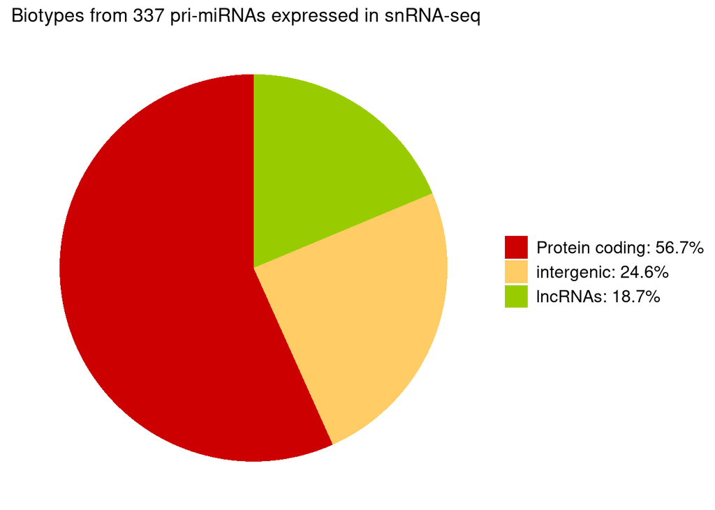

```r
SP064_pri_sub.sum <- Matrix::rowSums(SP064_pri_sub.dgCMatrix) %>% as.data.frame
colnames(SP064_pri_sub.sum) <- "counts"

SP064_pri_sub.sum$miRNA_ID <- rownames(SP064_pri_sub.sum)

SP064_pri_sub.sum <- SP064_pri_sub.sum[SP064_pri_sub.sum$counts >0, ] %>% as.data.frame

SP064_pri_sub.sum <- left_join(SP064_pri_sub.sum, host_biotype_unique_final, by = "miRNA_ID")


SP064_pri_sub.sum.df <- as.data.frame(table(SP064_pri_sub.sum$biotype))

SP064_pri_sub.sum.df$percent <- round(SP064_pri_sub.sum.df$Freq / sum(SP064_pri_sub.sum.df$Freq), 3)

ggplot(SP064_pri_sub.sum.df, aes(x = 2, y= percent, fill = factor(percent, levels = c(0.567, 0.246, 0.187)))) +
  geom_bar(width = 1, stat = "identity") +
  ggtitle("Biotypes from 337 pri-miRNAs expressed in snRNA-seq") +
  coord_polar(theta = "y", start=0) +
  theme_void() + theme(legend.text = element_text(size = 12), legend.title = element_blank()) +
  scale_fill_manual(values=c("#CC0000", "#FFCC66", "#99CC00"),
                    labels = c("Protein coding: 56.7%", "intergenic: 24.6%", "lncRNAs: 18.7%"))
```

#### 3. Biotypes of nUMI counts of pri-miRNA in AD snRNA-seq data

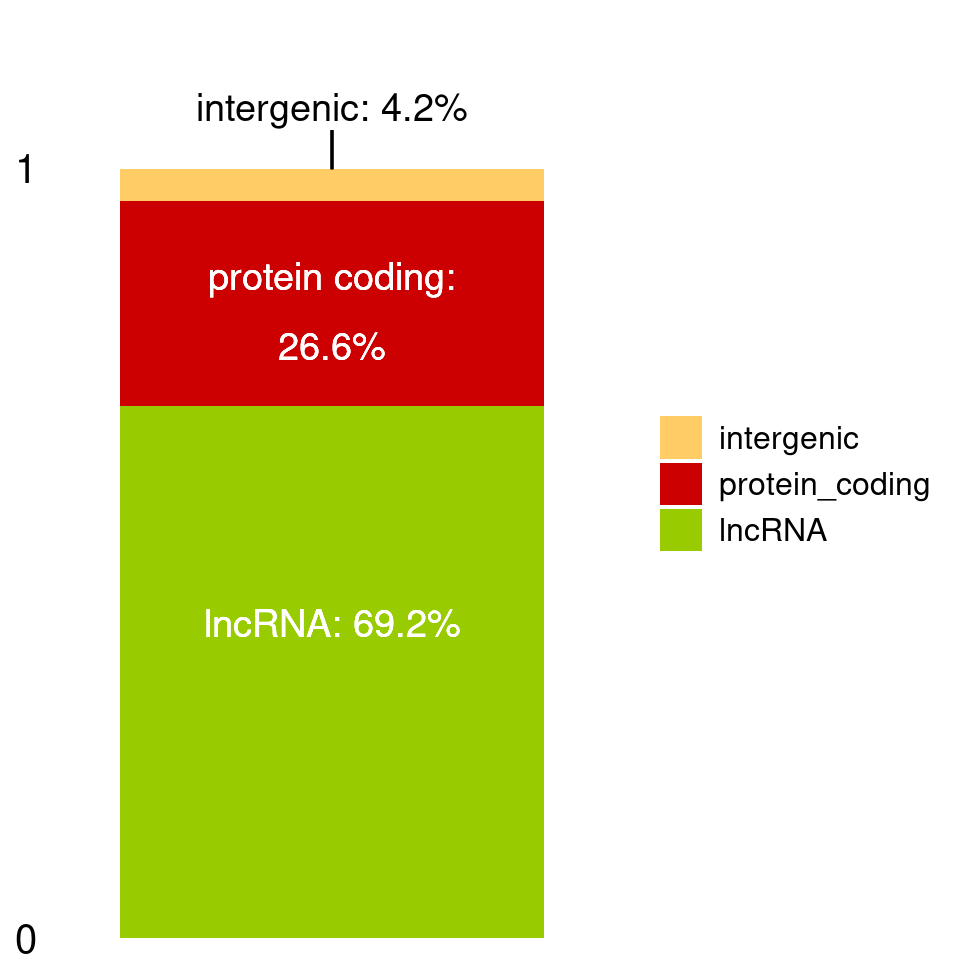

```r
SP064_pri_sub.sum.df2 <- SP064_pri_sub.sum %>% group_by(biotype) %>% summarise(all = sum(counts))

SP064_pri_sub.sum.df2$percent <- round(SP064_pri_sub.sum.df2$all / sum(SP064_pri_sub.sum.df2$all), 3)

SP064_pri_sub.sum.df2$biotype <- factor(SP064_pri_sub.sum.df2$biotype, levels = c("intergenic", "protein_coding", "lncRNA"))

ggplot(SP064_pri_sub.sum.df2, aes(fill=biotype, y=percent, x="gene_biotype")) +
    geom_bar(position="fill", stat="identity") +
  theme_classic() +
  geom_text(aes(y=0.45, label="lncRNA: 69.2%"), vjust=1.6, color="white", size=5) +
  geom_text(aes(y=0.90, label="protein coding:"), vjust=1.6, color="white", size=5) +
  geom_text(aes(y=0.81, label="26.6%"), vjust=1.6, color="white", size=5) +
  scale_y_continuous(expand = c(0,0), limits = c(0,1.2), breaks = c(0,1)) +
  theme(axis.text.x = element_blank(),
        axis.text.y = element_text(size = 15, color = "black"),
        axis.title = element_blank(),
        axis.line = element_blank(),
        axis.ticks = element_blank(),
        legend.title = element_blank(),
        legend.text = element_text(size = 12)) +
  annotate(geom="text", x=1, y=1.08, label="intergenic: 4.2%", color="black", size = 5) +
  scale_fill_manual(values=c("#FFCC66", "#CC0000", "#99CC00")) +
  geom_segment(aes(x = 1, y = 0.999, xend = 1, yend = 1.05),color='black',size=0.5)
```

#### 4. Top 10 expressed pri-miRNA and its host gene

High number of lncRNAs due to Meg3 which is highly expressed in hippocampus

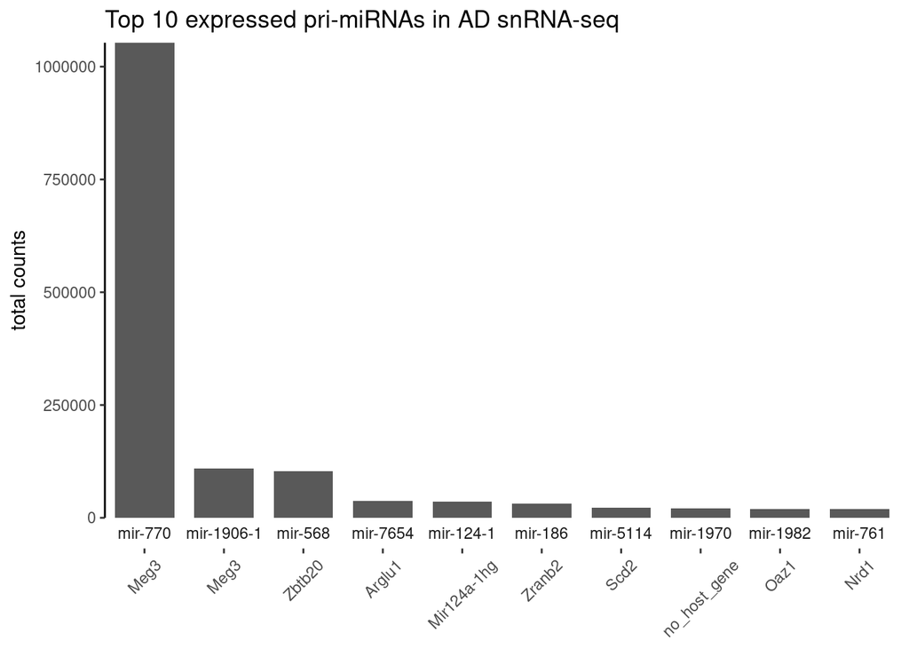

```r
SP064_pri_sub.sum_top10 <- SP064_pri_sub.sum[rev(order(SP064_pri_sub.sum$counts))[1:10], ]

SP064_pri_sub.sum_top10 <- left_join(SP064_pri_sub.sum_top10, host_biotype_unique_final, by = "miRNA_ID")

SP064_pri_sub.sum_top10$miRNA_ID <- factor(SP064_pri_sub.sum_top10$miRNA_ID, levels = SP064_pri_sub.sum_top10$miRNA_ID)

ggplot(SP064_pri_sub.sum_top10, aes(x = host_gene.x, y = counts)) + geom_bar(stat="identity") + facet_grid(.~ miRNA_ID, space = 'free_x', scales = 'free_x', switch = 'x') +
  ggtitle("Top 10 expressed pri-miRNAs in AD snRNA-seq") +
  scale_y_continuous(expand = c(0,0)) +
  theme_classic() + ylab("total counts") +
  theme(panel.spacing = unit(0.01, "lines"), axis.title.x = element_blank(), axis.text.x = element_text(angle = 45, vjust = 0.5), strip.background = element_blank(),
        axis.line.x = element_blank())
```

```r
SP064_all <- Read10X("/data/rajewsky/home/skim/Microglia_Heppner/201912_10X_9sets/SP064_All_025_3p/outs/filtered_feature_bc_matrix/")

###################################
# Extract only intergenic pri-miRNA
###################################
SP064_pri_sub.intergenic_dgCMatrix <- SP064_pri_sub.dgCMatrix[rownames(SP064_pri_sub.dgCMatrix) %in% SP064_pri_sub.sum[SP064_pri_sub.sum$biotype %in% c("intergenic"), ]$miRNA_ID, ]

SP064_all_sub <- SP064_all[, colnames(SP064_all) %in% Cells(data9set_cleaned.SO)]

SP064_all_sub <- rbind(SP064_all_sub, SP064_pri_sub.intergenic_dgCMatrix)

data9set.SO <- CreateSeuratObject(counts =  SP064_all_sub,  min.cells = 3, min.features = 200, project = "AD_Project")

# add gemgroup to meta data
gemgroup <- sapply(strsplit(rownames(data9set.SO@meta.data), split="-"), "[[", 2)
data9set.SO <- AddMetaData(object=data9set.SO, metadata=data.frame(gemgroup=gemgroup, row.names=rownames(data9set.SO@meta.data)))

# calculate MT genes
data9set.SO[["percent.mt"]] <- PercentageFeatureSet(object = data9set.SO, pattern = "^mt-")

data9set.SO <- subset(x = data9set.SO, subset = nCount_RNA < 30000 & nCount_RNA > 500 & percent.mt < 5)

data9set.SO <- NormalizeData(object = data9set.SO, normalization.method = "LogNormalize", scale.factor = 1e4, verbose = FALSE)

data9set.SO@meta.data <- data9set_cleaned.SO@meta.data

data9set.SO@active.assay <- data9set_cleaned.SO@active.assay

data9set.SO@active.ident <- data9set_cleaned.SO@active.ident

data9set.SO@reductions <- data9set_cleaned.SO@reductions

#save(data9set.SO, file = "/data/rajewsky/home/skim/Microglia_Heppner/201912_10X_9sets/miRNA_lncRNA/R_Scripts/20200505_pri_miRNA_dgCMatrix_Create_Seurat_with_intergenic_pri_miRNA.obj")
```

#### 5. e.g. of interesting candidates

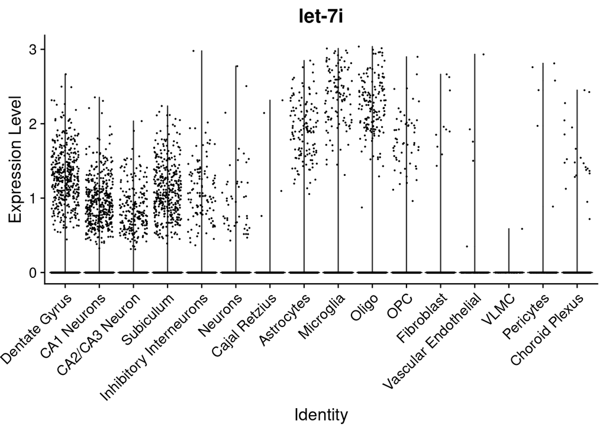

```r
VlnPlot(data9set.SO, features = "let-7i", pt.size = 0.1) + theme(legend.position = "none")
```

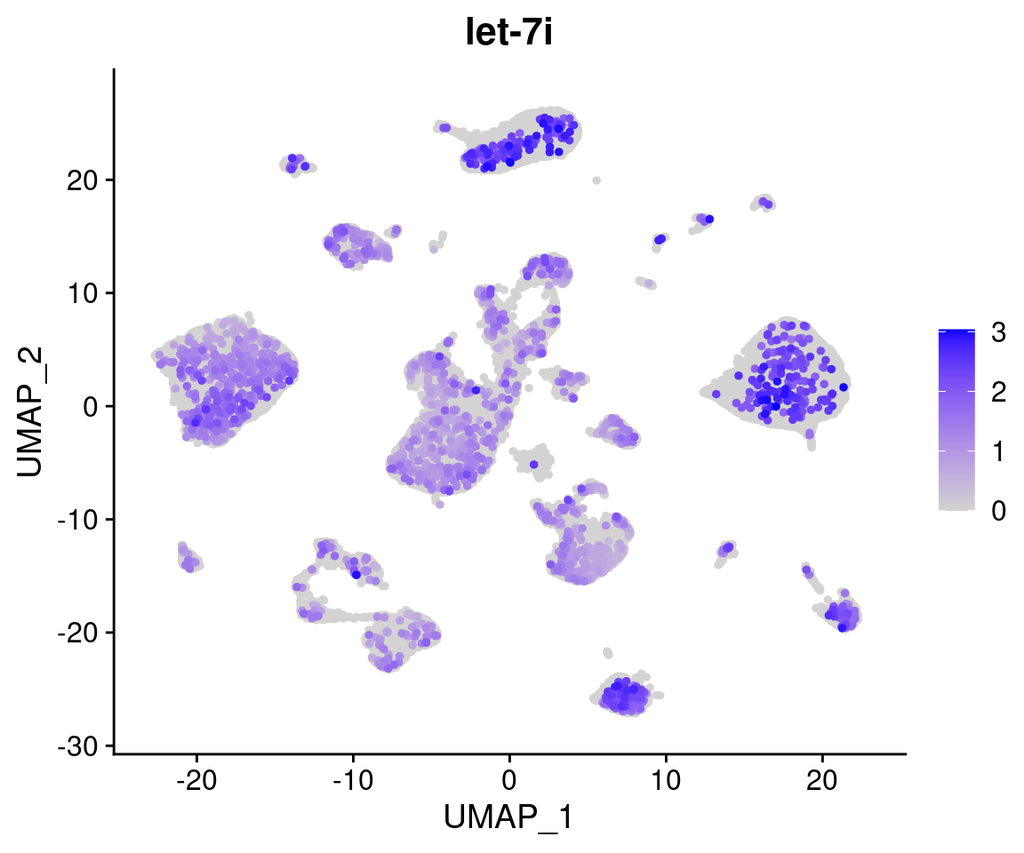

```r
FeaturePlot(data9set.SO, features = "let-7i", order = TRUE, pt.size = 1)
```

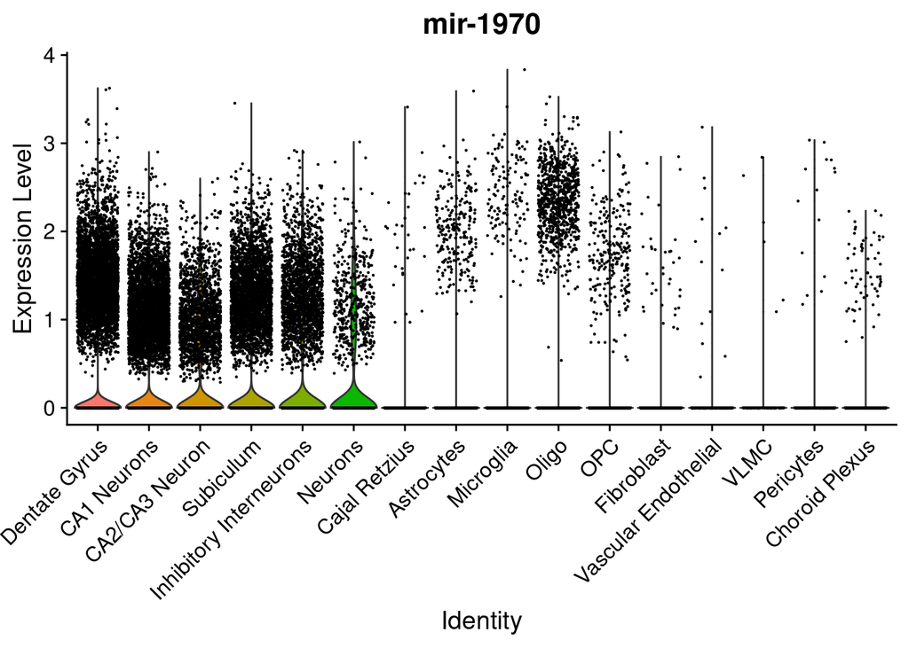

```r
VlnPlot(data9set.SO, features = "mir-1970", pt.size = 0.1) + theme(legend.position = "none")
```

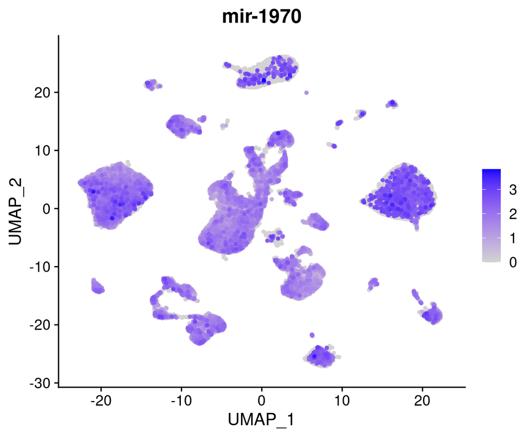

```r
FeaturePlot(data9set.SO, features = "mir-1970", order = TRUE, pt.size = 1)
```

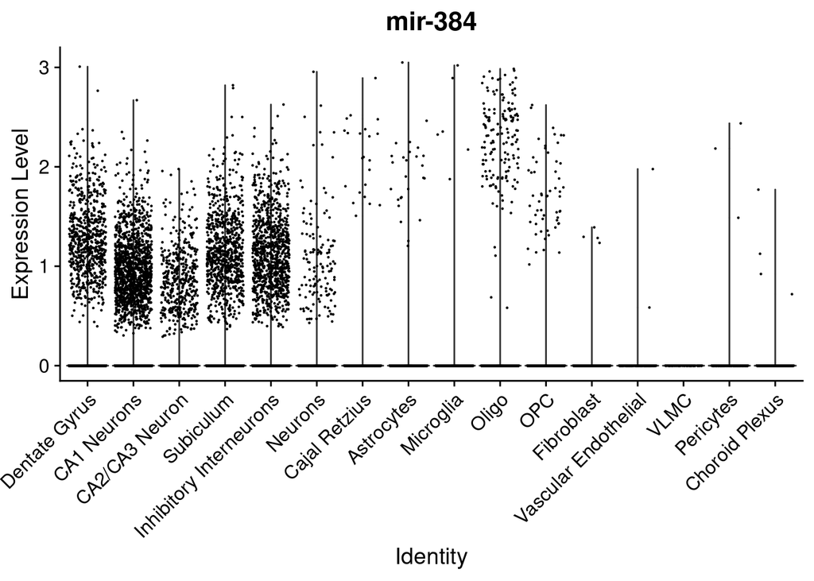

```r
VlnPlot(data9set.SO, features = "mir-384", pt.size = 0.1)+ theme(legend.position = "none")
```

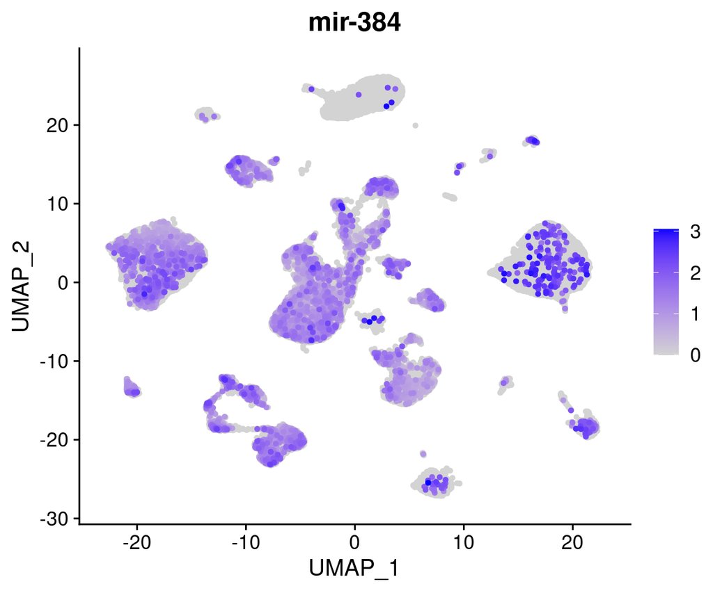

```r
FeaturePlot(data9set.SO, features = "mir-384", order = TRUE, pt.size = 1)
```

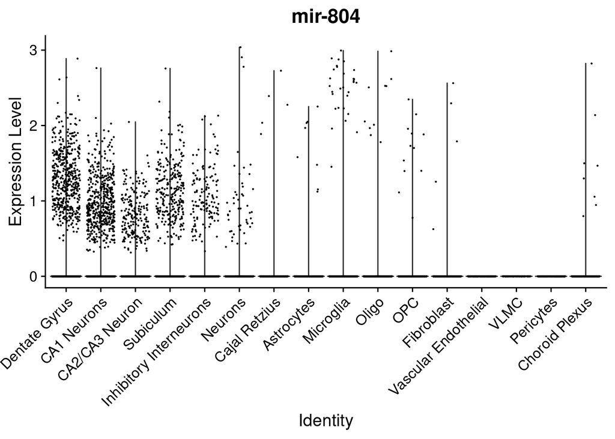

```r
VlnPlot(data9set.SO, features = "mir-804", pt.size = 0.1)+ theme(legend.position = "none")
```

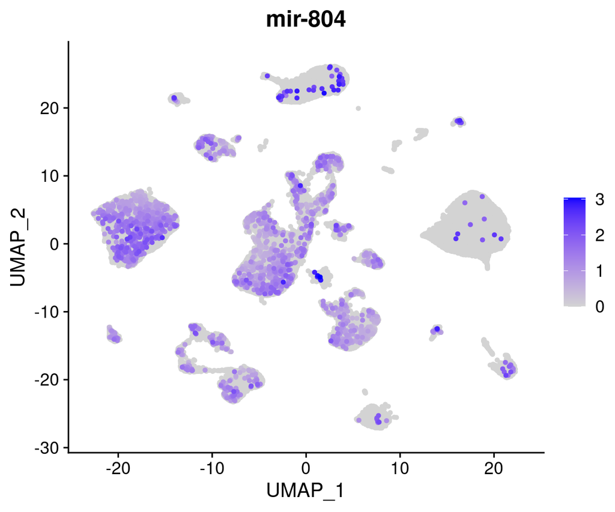

```r
FeaturePlot(data9set.SO, features = "mir-804", order = TRUE, pt.size = 1)
```

```r
SP064_pri_sub.SO <- CreateSeuratObject(SP064_pri_sub.dgCMatrix)

#SP064_pri_sub.SO@meta.data

# add gemgroup to meta data
gemgroup <- sapply(strsplit(rownames(SP064_pri_sub.SO@meta.data), split="-"), "[[", 2)

SP064_pri_sub.SO <- AddMetaData(object=SP064_pri_sub.SO, metadata=data.frame(gemgroup=gemgroup, row.names=rownames(SP064_pri_sub.SO@meta.data)))

SP064_pri_sub.SO@meta.data$sample <- ifelse((SP064_pri_sub.SO$gemgroup == 1 | SP064_pri_sub.SO$gemgroup == 4 | SP064_pri_sub.SO$gemgroup == 7), "Ctrl", ifelse((SP064_pri_sub.SO$gemgroup == 2 | SP064_pri_sub.SO$gemgroup == 5 | SP064_pri_sub.SO$gemgroup == 8), "ADp40KO", "AD"))
```

#### 6. Overview

Detected **11** pri-miRNAs UMI counts per cell.

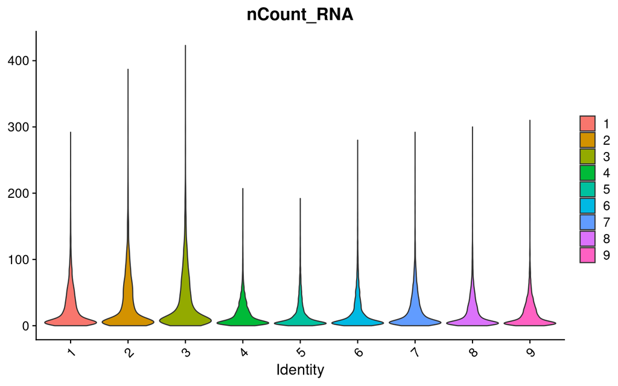

```r
VlnPlot(SP064_pri_sub.SO, features = c("nCount_RNA"), group.by = "gemgroup", pt.size = 0)
```

```r
#median(SP064_pri_sub.SO$nCount_RNA)
```

```r
#FeatureScatter(SP064_pri_sub.SO, feature1 = "nCount_RNA", feature2 = "nFeature_RNA")
```

#### 7. Interesting pri-miRNAs

Below analysis was done only by pri-miRNAs (normalized by only pri-miRNAs) and interesting DE genes from intergenic pri-miRNAs

```r
SP064_pri_sub.SO <- NormalizeData(object = SP064_pri_sub.SO, normalization.method = "LogNormalize", scale.factor = 1e4, verbose = FALSE)


#SP064_pri_sub_DE_whole_AD_Ctrl <- FindMarkers(SP064_pri_sub.SO, ident.1 = "AD", ident.2 = "Ctrl", group.by = "sample", logfc.threshold = 0.1, min.pct = 0.01)

#write.csv(SP064_pri_sub_DE_whole_AD_Ctrl, file = "/data/rajewsky/home/skim/Microglia_Heppner/201912_10X_9sets/miRNA_lncRNA/R_Scripts/20200505_pri_miRNA_dgCMatrix_Create_SP064_pri_sub_DE_whole_AD_Ctrl.csv")
SP064_pri_sub_DE_whole_AD_Ctrl <- read.csv(file = "/data/rajewsky/home/skim/Microglia_Heppner/201912_10X_9sets/miRNA_lncRNA/R_Scripts/20200505_pri_miRNA_dgCMatrix_Create_SP064_pri_sub_DE_whole_AD_Ctrl.csv")
SP064_pri_sub_DE_whole_AD_Ctrl[SP064_pri_sub_DE_whole_AD_Ctrl$X %in% SP064_pri_sub.sum[SP064_pri_sub.sum$biotype %in% "intergenic", ]$miRNA_ID, ]
```

|  | X | p_val | avg_logFC | pct.1 | pct.2 | p_val_adj |
| --- | --- | --- | --- | --- | --- | --- |
| 9 | mir-5136 | 1.556210e-09 | 0.2550884 | 0.024 | 0.017 | 5.882475e-07 |
| 15 | mir-1970 | 5.381193e-06 | -0.1201774 | 0.208 | 0.221 | 2.034091e-03 |
| 16 | let-7i | 1.248372e-05 | 0.1979336 | 0.029 | 0.023 | 4.718845e-03 |
| 23 | mir-467f | 1.476707e-03 | -0.2743281 | 0.031 | 0.036 | 5.581953e-01 |
| 31 | mir-804 | 1.481230e-02 | 0.2500731 | 0.024 | 0.021 | 1.000000e+00 |
| 38 | mir-6340 | 8.720169e-02 | 0.2244974 | 0.012 | 0.011 | 1.000000e+00 |
| 42 | mir-8109 | 5.050523e-01 | -0.1574264 | 0.020 | 0.020 | 1.000000e+00 |
| 48 | mir-384 | 9.958605e-01 | -0.1527355 | 0.057 | 0.057 | 1.000000e+00 |

```r
# data9set_cleaned_DE_whole_AD_Ctrl <- FindMarkers(data9set_cleaned.SO, ident.1 = "AD", ident.2 = "Ctrl", group.by = "sample", logfc.threshold = 0.1, min.pct = 0.01)
#
# data9set_cleaned_DE_whole_AD_Ctrl$gene <- rownames(data9set_cleaned_DE_whole_AD_Ctrl)
#
# data9set_cleaned_DE_whole_AD_ADp40KO <- FindMarkers(data9set_cleaned.SO, ident.1 = "AD", ident.2 = "ADp40KO", group.by = "sample", logfc.threshold = 0.1, min.pct = 0.01)
#
# data9set_cleaned_DE_whole_AD_ADp40KO$gene <- rownames(data9set_cleaned_DE_whole_AD_ADp40KO)
#
# write.csv(data9set_cleaned_DE_whole_AD_Ctrl, file = "/data/rajewsky/home/skim/Microglia_Heppner/201912_10X_9sets/miRNA_lncRNA/R_Scripts/20200505_pri_miRNA_dgCMatrix_Create_data9set_cleaned_DE_whole_AD_Ctrl.csv")
 # data9set_cleaned_DE_whole_AD_Ctrl <- read.csv(file = "/data/rajewsky/home/skim/Microglia_Heppner/201912_10X_9sets/miRNA_lncRNA/R_Scripts/20200505_pri_miRNA_dgCMatrix_Create_data9set_cleaned_DE_whole_AD_Ctrl.csv")

#
# write.csv(data9set_cleaned_DE_whole_AD_ADp40KO, file = "/data/rajewsky/home/skim/Microglia_Heppner/201912_10X_9sets/miRNA_lncRNA/R_Scripts/20200505_pri_miRNA_dgCMatrix_Create_data9set_cleaned_DE_whole_AD_ADp40KO.csv")
#
#
# data9set_cleaned_DE_whole_AD_Ctrl <- read.csv(file = "/data/rajewsky/home/skim/Microglia_Heppner/201912_10X_9sets/miRNA_lncRNA/R_Scripts/20200505_pri_miRNA_dgCMatrix_Create_data9set_cleaned_DE_whole_AD_Ctrl.csv", row.names = 1)
```